# Analyse des modèles

## Chargement des données

Nous nous sommes basés sur la base de données “models_v3”, reprenant les informations disponibles sur chacun des modèles présent sur la plateforme.

```r
data <- read.csv('C:/Users/tryst/Desktop/EDC/models_v3.csv')
```

Ainsi, voici l’ensemble des variables que nous possédons sur nos modèles :

| x |
| --- |
| URL |
| Name |
| Bio |
| Subscribers |
| Videos_views |
| Pornhub_rank |
| Model_rank |
| Public_videos |
| Paid_videos |
| Fan_club_material |
| Verified_pornstar |
| Verified_member |
| Premium_user |
| Pornhub_awards_winner |
| Age |
| Background |
| Birthday |
| Birthplace |
| Born |
| Career.Start.and.End |
| Career.Status |
| City.and.Country |
| Endowment |
| Ethnicity |
| Eye.Color |
| Facial.Hair |
| Fake.Boobs |
| Foreskin |
| Gender |
| Hair.Color |
| Height |
| Weight |
| Interested.in |
| Interests.and.hobbies |
| Joined |
| Measurements |
| Piercings |
| Pornstar.Profile.Views |
| Profile.Views |
| Relationship.status |
| Star.Sign |
| Tattoos |
| Turn.Offs |
| Turn.Ons |
| Video.Views |
| Videos.Watched |
| Hometown |

## Visualisation des données de notre base

### Nombre de modèles par pays

On peut voir rapidement la présence des modèles dans le monde :

Nombre de modèles dans les 10 premiers pays

| Pays de naissance | Nombre de modèles |
| --- | --- |
| Non renseigné | 52848 |
| USA | 15199 |
| Canada | 1347 |
| Russia | 905 |
| United Kingdom | 862 |
| Mexico | 622 |
| Colombia | 537 |
| France | 492 |
| Italy | 455 |
| Australia | 420 |

### Date d’inscription de nos modèles

La variable Joined nous donne accès à l’ancienneté du modèle sur la plateforme.

Mis en forme avec l’âge, on pourra ainsi déterminer l’ancienneté moyenne d’un modèle en fonction de son âge :

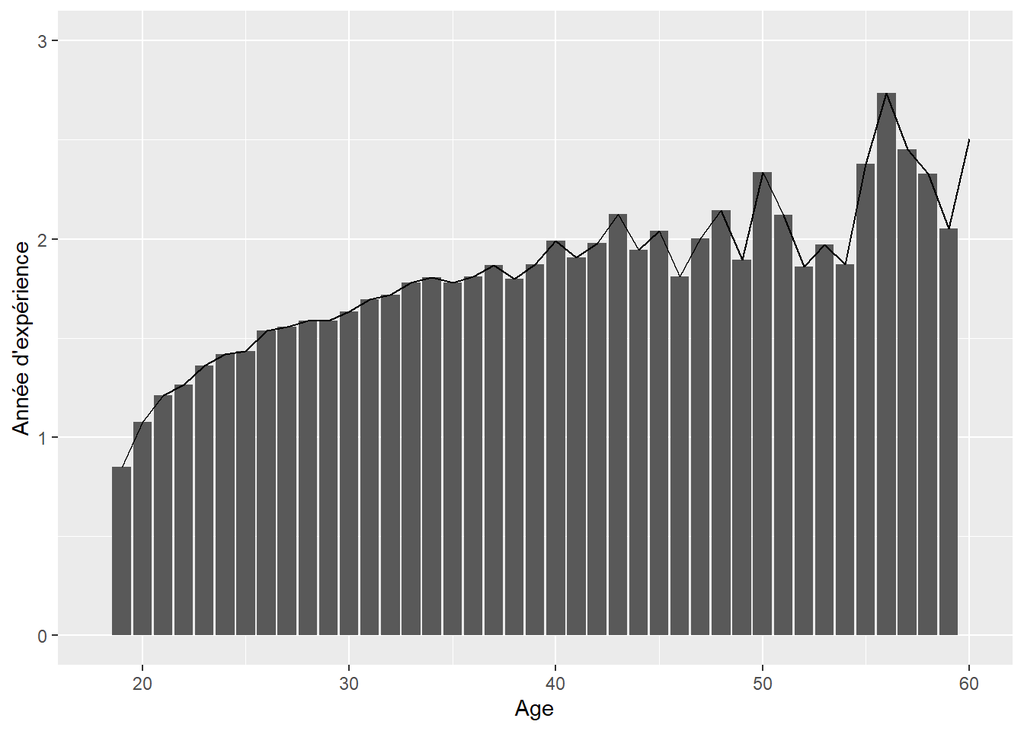

### Répartition selon le genre parmi nos modèles

Notre base de données contenant plus de 70 000 modèles venant d’horizons différents, on peut observer la répartition des genres dans notre échantillon. En effet, on voit dans la plupart des cas des hommes, des femmes et des couples, mais d’autres apparaissent comme des non-binaires, des transgenres etc.

Voici la répartition des différents genres parmis nos modèles :

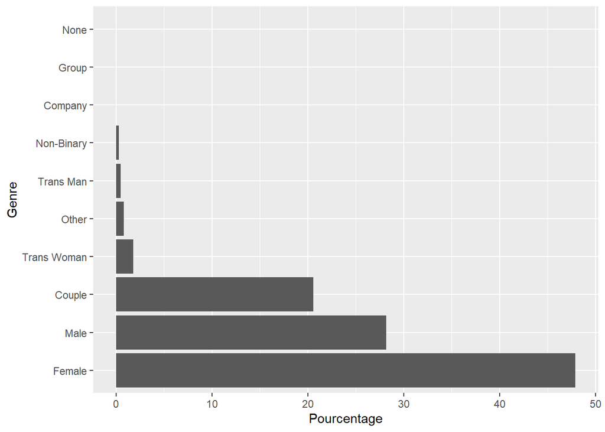

On voit alors que le genre Femme / Couple / Homme est très présent, voyons la répartition de leur âge :

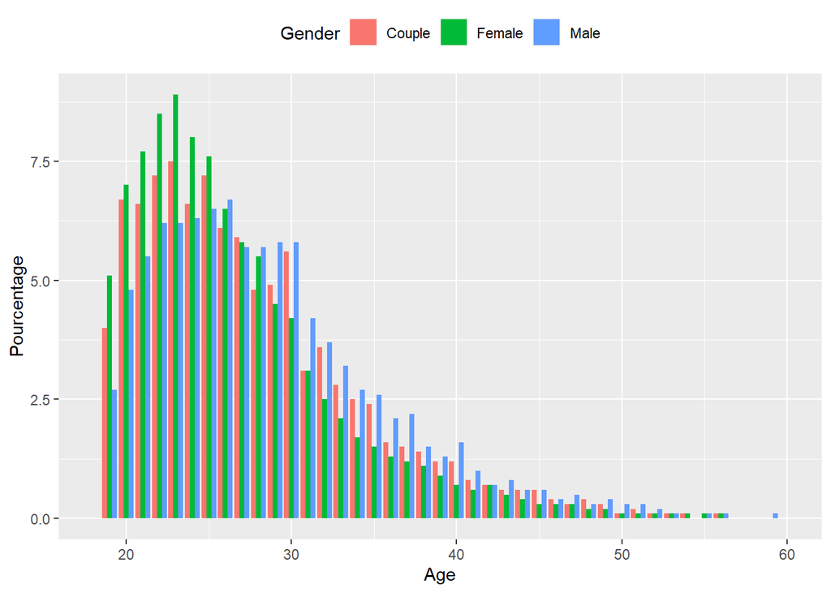

### Visualisation des meilleures modèles par pays, leurs caractéristiques ainsi que celles des modèles du pays

Une étude démographique semble intéressante pour déterminer les différences dans chacun des pays.

Ainsi, deux informations peuvent se dégager lors du survol d’un pays :

- Les informations sur le modèle le plus connu du pays (avec un lien direct vers son profil), avec les informations sur son genre, son âge, son ethnicité et son nombre d’abonnés.
- Les informations sur les modèles du pays, avec le nom du pays, nombre de modèles, et le pourcentage de modèles tatoués dans ce pays

[interactive chart not shown]